# Experimental citation analyst

2014-12-09

You’ll find this post in your `_posts` directory. Go ahead and edit it and re-build the site to see your changes. You can rebuild the site in many different ways, but the most common way is to run `jekyll serve`, which launches a web server and auto-regenerates your site when a file is updated.

To add new posts, simply add a file in the `_posts` directory that follows the convention `YYYY-MM-DD-name-of-post.ext` and includes the necessary front matter. Take a look at the source for this post to get an idea about how it works.

Jekyll also offers powerful support for code snippets

```r
require(rCharts)
require(googleVis)
nodes_network <- read.csv("~/Development/env/citation_network/nodes_network.csv",
    sep = ";")
dataSub <- subset(nodes_network, !(group == 1))
cdata <- aggregate(dataSub["id"], by = dataSub[c("country")], FUN = length)
names(cdata) <- c("Country", "No.Inventors")
Geo = gvisGeoChart(cdata, "Country", "No.Inventors", options = list(gvis.editor = "S&P",
    projection = "kavrayskiy-vii", colorAxis = "{colors:['#91BFDB', '#FC8D59']}"))

print(Geo, "chart")
```

[output not shown]

```r
summary(cars)
```

```
##      speed           dist
##  Min.   : 4.0   Min.   :  2.00
##  1st Qu.:12.0   1st Qu.: 26.00
##  Median :15.0   Median : 36.00
##  Mean   :15.4   Mean   : 42.98
##  3rd Qu.:19.0   3rd Qu.: 56.00
##  Max.   :25.0   Max.   :120.00
```

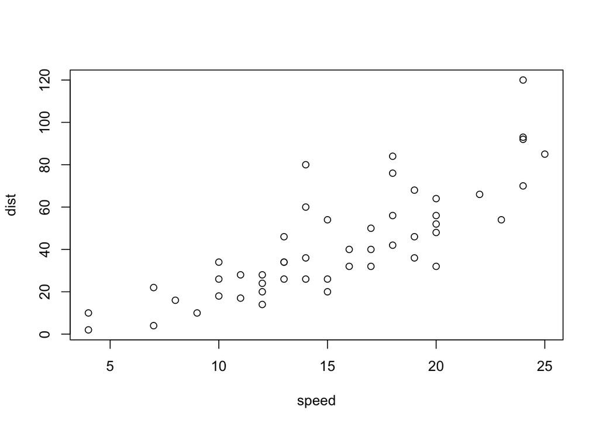

```r
a=5+2
plot(cars)
```

Check out the [Jekyll docs](http://jekyllrb.com) for more info on how to get the most out of Jekyll. File all bugs/feature requests at [Jekyll’s GitHub repo](https://github.com/jekyll/jekyll). If you have questions, you can ask them on [Jekyll’s dedicated Help repository](https://github.com/jekyll/jekyll-help).